# PEC1

UOC

Otoño 2024

# 1 Objetivos del aprendizaje

El objetivo de esta actividad es introducir al estudiante en el análisis descriptivo de los datos con `R`.

En esta PEC seguiremos utilizando el conjunto de datos ‘worlcup’ sobre la copa mundial de fútbol celebrada en Sudáfrica el año 2010.

Recordemos que es una tabla de datos donde las filas representan jugadores y las columnas características de dichos jugadores.

Las variables o características de los jugadores que nos interesan son las siguientes:

1. `Team`: equipo al que pertenece el jugador.
2. `Position`: posición en la que juega el jugador: `Defender` (defensa), `Forward` (delantero), `Goalkeeper` (portero) o `Midfielder` (centrocampista).
3. `Time`: tiempo que ha jugado el jugador en minutos.
4. `Shots`: número de tiros a puerta realizados por el jugador.
5. `Passes`: número de pases realizados por el jugador.
6. `Tackles`: número de entradas realizadas por el jugador.
7. `Saves`: número de paradas realizadas por el jugador.

Importante:

1. Esta PEC debe realizarse de forma estrictamente individual, quedando del todo prohibido el uso de herramientas de IA. Cualquier indicio de copia será penalizado con un suspenso (D) por todas las partes implicadas y la posible evaluación negativa de la asignatura de forma íntegra.
2. Es necesario que el estudiante indique todas las fuentes que ha utitlizado para la realización de la PEC. De no ser así, se considerará que el estudiante ha cometido plagio, siendo penalizado con un suspenso (D) y la posible evaluación negativa de la asignatura de manera íntegra.

# 2 Preparar el conjunto de datos (0.5 puntos)

- Para realizar esta PEC, puedes partir de los objetos `worldcup` y `worldcup.Spain` generados como resultado de la PEC0.
- Si no realizaste la PEC0, bájate la solución y copia todos los pasos realizados.

## Solución

```r
# cargamos el paquete "faraway" para acceder al dataframe "worldcup"
library(faraway)
head(worldcup)
```

```
##                Team   Position Time Shots Passes Tackles Saves
## Abdoun      Algeria Midfielder   16     0      6       0     0
## Abe           Japan Midfielder  351     0    101      14     0
## Abidal       France   Defender  180     0     91       6     0
## Abou Diaby   France Midfielder  270     1    111       5     0
## Aboubakar  Cameroon    Forward   46     2     16       0     0
## Abreu       Uruguay    Forward   72     0     15       0     0
```

```r
# hacemos una copia para no modificar el original,lo llamaremos "dfgol" por cambiar un poco.
dfgol = worldcup

# vamos a seleccionar los jugadores de España en un nuevo dataframe "worldcup.Spain", como dice el enunciado.
worldcup.Spain = dfgol[dfgol$Team == "Spain",]

# vemos los primeros valores de la nueva tabla generada.
head(worldcup.Spain)
```

```
##            Team   Position Time Shots Passes Tackles Saves
## Alonso    Spain Midfielder  506     9    465      18     0
## Arbeloa   Spain   Defender   13     0     12       0     0
## Busquets  Spain Midfielder  511     0    466      15     0
## Capdevila Spain   Defender  540     1    310      10     0
## Casillas  Spain Goalkeeper  540     0     67       0    11
## Fabregas  Spain Midfielder   94     1    116       2     0
```

En toda la PEC vamos a usar la tabla de datos `worldcup.Spain`.

# 3 Ordenar valores (1.5 puntos)

- ¿Cuáles son los 10 jugadores españoles que han jugado más tiempo?
- ¿Cuáles son los 10 jugadores españoles que han jugado menos tiempo?

## Solución

```r
# En la variable "mas.Time" vamos a guardar el resultado que se pasará a explicar más abajo.

mas.Time = head(worldcup.Spain[order(worldcup.Spain$Time, decreasing= TRUE), ], 10)
mas.Time
```

```
##            Team   Position Time Shots Passes Tackles Saves
## Capdevila Spain   Defender  540     1    310      10     0
## Casillas  Spain Goalkeeper  540     0     67       0    11
## Pique     Spain   Defender  540     2    402      15     0
## Puyol     Spain   Defender  534     3    254       8     0
## Villa     Spain    Forward  529    22    169       2     0
## Ramos     Spain   Defender  527     9    299       7     0
## Xavi      Spain Midfielder  515     4    563       6     0
## Busquets  Spain Midfielder  511     0    466      15     0
## Alonso    Spain Midfielder  506     9    465      18     0
## Iniesta   Spain Midfielder  437     8    299      11     0
```

```r
# lo hemos puesto todo en una misma línea que pasamos a explicar de dentro hacia fuera;
# "worldcup.Spain$Time", seleccionamos del dataframe worldcup.Spain la variable "Time"
# lo ordenamos con "order" y el argumeto "decreasing" para elegir si es creciente o decreciente, en este caso "TRUE" lo hace decreciente.
# todo esto lo colocamos dentro del dataframe "worldcup.Spain" en corchetes para seccionar una subtabla. Importante la "," para que generar la subtabla y lo listamos con un "head" y un "10" para que salgan los 10 primeros resultados.

# hagamos los mismo con los 10 jugadores con menos tiempo pero esta vez utilizando "decrerasing = FALSE" para un resultado creciente en la subtabla.

menos.Time = head(worldcup.Spain[order(worldcup.Spain$Time, decreasing = FALSE), ], 10)
menos.Time
```

```
##                  Team   Position Time Shots Passes Tackles Saves
## Marchena        Spain   Defender    8     0      1       0     0
## Arbeloa         Spain   Defender   13     0     12       0     0
## Javi Martinez   Spain Midfielder   17     0     17       0     0
## Juan Mata       Spain Midfielder   20     1     16       0     0
## Llorente        Spain    Forward   31     2     12       0     0
## Silva           Spain Midfielder   66     2     42       2     0
## Fabregas        Spain Midfielder   94     1    116       2     0
## Pedro Rodriguez Spain Midfielder  116     5     80       0     0
## Jesus Navas     Spain Midfielder  118     4     61       1     0
## TorresF         Spain    Forward  278     9     50       0     0
```

## 3.1 Comentario

A modo de comentario podemos destacar de la subtabla de los 10 jugadores que ha jugado más tiempo, que tenemos un triple empate, pues con 540 min jugados están, los defensores Capdevila y Piqué y Casillas como el único portero.

De los jugadores que menos tiempo han jugado, destacamos a Marchena como defensor que ha jugado tan solo 8 minutos, seguido por Albeola con 13 minutos jugados.

# 4 Estadísticas descriptivas (3 puntos)

- Calcular la media y desviación estándar del tiempo de juego de los jugadores españoles dependiendo de la posición en que juegan, es decir, para cada posición en la juega un jugador hay que calcular la media y la desviación estándar de todos los tiempos de juego.
- Dibujar un boxplot de los tiempos de juego para cada posición del jugador.
- Comentar los resultados obtenidos.

## Solución

```r
# lo primero tenemos que conocer el nombre de las funciones de la media y la desviación estandar, "mean()" y "sd()", respectivamente.
# con "by" lo que vamos a hacer es listar por factores y como nos pide el enunciado vamos a listar por la variable factor "Position"
media.Position = by(worldcup.Spain$Time, worldcup.Spain$Position, mean)
media.Position
```

```
## worldcup.Spain$Position: Defender
## [1] 360.3333
## ------------------------------------------------------------
## worldcup.Spain$Position: Forward
## [1] 279.3333
## ------------------------------------------------------------
## worldcup.Spain$Position: Goalkeeper
## [1] 540
## ------------------------------------------------------------
## worldcup.Spain$Position: Midfielder
## [1] 240
```

```r
# a la orden "by" se le pasan 3 argumentos, primero la variable cuantitativa, en este caso "Time" , segundo una variable cualitativa, y lo tercero la función, en este caso "mean()" de la media.

# para el caso de la desviación estandar, hacemos lo mismo, pero cambiando la función por "sd".

desvi.Position = by(worldcup.Spain$Time, worldcup.Spain$Position, sd)
desvi.Position
```

```
## worldcup.Spain$Position: Defender
## [1] 271.0267
## ------------------------------------------------------------
## worldcup.Spain$Position: Forward
## [1] 249.0027
## ------------------------------------------------------------
## worldcup.Spain$Position: Goalkeeper
## [1] NA
## ------------------------------------------------------------
## worldcup.Spain$Position: Midfielder
## [1] 220.7593
```

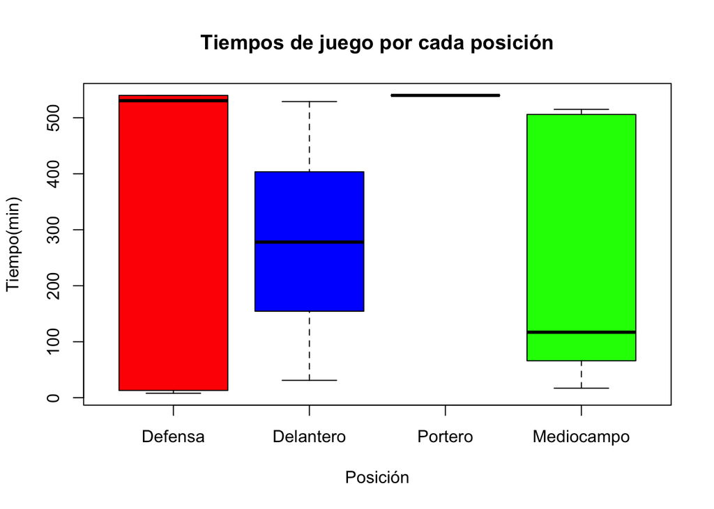

```r
# ahora vamos a graficar un boxplot con los tiempos de juego de cada posición del jugador

boxplot(Time~Position, worldcup.Spain, main="Tiempos de juego por cada posición",
        xlab= "Posición", ylab= "Tiempo(min)", names=c("Defensa","Delantero","Portero","Mediocampo"), col= c("red","blue","lightblue","green"))
```

```r
# pasemos a explicar el proceso de creación, para que relacione una variable numerica y una variable categorica en un boxplot necesitamos "~" uniendo las dos variables, sería el primer argumento para el boxplot.
# como segundo argumento le pasamos el dataframe, en este caso "worldcup.Spain"
# ahora vamos a adornar un poco el boxplot,con varios argumentos. Un título "main",
# leyenda en el eje x e y "xlab" "ylab" , le cambiamos el nombre de las posisciones al    castellano "names" y le ponemos un poco de color al boxplot "col".
```

## 4.1 Comentario

Para empezar lo primero que nos llama la atención en el boxplot es la categoría de “**Portero”**, solo está Casillas y tiene 540 min jugados, por lo que, al haber sólo un portero los *stats* (*min, Q1, Mediana, Q3 y max*) van a ser para todas las medidas 540.

Lo siguiente en llamarnos la atención son las categorías de “**Defensa**” y “**Mediocampo**”, pocos defensas han jugado minutos siendo el **minimo 8**.De los 6 defensas, 4 han jugado más de 500 minutos(*max 540*), por lo que la mediana(*530.5*) se encuentra más cerca de 540 como podemos observar en el gráfico. Lo contrario pasa con los jugadores de mediocampo pues de los 10 jugadores con esta categoría solo 3 superan los 500 minutos jugados y eso hace tener una mediana baja(*117*) y tener un rango de Q2 hasta Q3(*506*) tan amplio.

# 5 Eliminación de outliers (2.5)

- Eliminar los outliers de la variable `Tiros`. Construir la tabla de datos `worldcup.Spain.sin.outliers`.
- Comparar los boxplots de la variable `Tiros` de la tabla de datos original (`worldcup.Spain`), es decir, con los datos originales sin eliminar los outliers y la nueva subtabla de datos `worldcup.Spain.sin.outliers`.
- Interpretar los resultados

## Solución

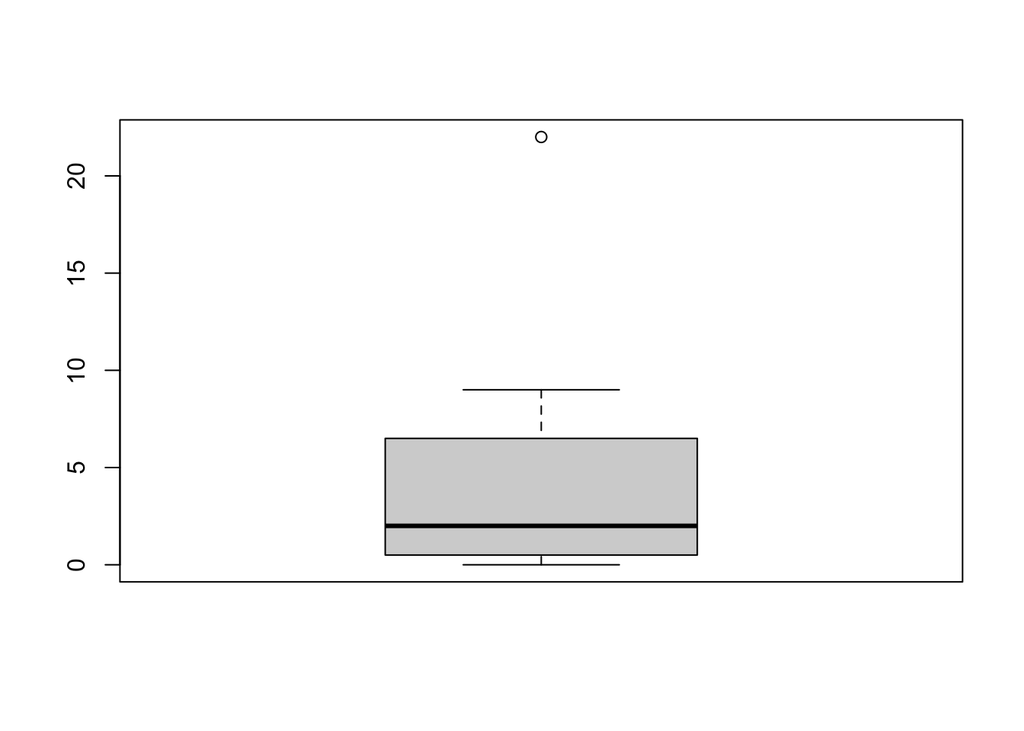

```r
# para eliminar los outliers de la variable "tiros" debemos localizarlo y para ello
# obtenemos el valor del outlier con "$out" al final del parentesis
outliers <- boxplot(worldcup.Spain$Shots)$out
```

```r
print(paste("El valor del outlier es: ", outliers))
```

```
## [1] "El valor del outlier es:  22"
```

```r
# vamos a seleccionar el índice del outlier contenido en la variable "outliers" que hemos creado pues para generar una subtabla sin él debemos conocer su índice. Gracias a "which" podemos conocer el indice del valor contenido en "outliers"
sin.outlier = which(worldcup.Spain$Shots %in% outliers)
print(paste("El índice de nuestro outlier en la variable 'sin.outlier' es:" , sin.outlier))
```

```
## [1] "El índice de nuestro outlier en la variable 'sin.outlier' es: 19"
```

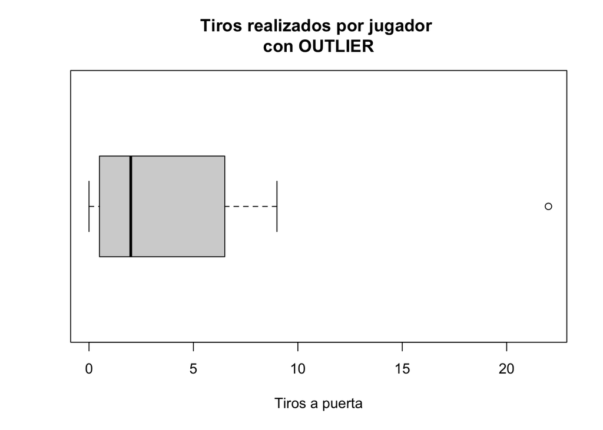

```r
# generamos una tabla sin el valor outlier en la variable tiros
worldcup.Spain.sin.outliers <- worldcup.Spain[-sin.outlier, ]# la "," simpre importante
# comprobamos que hemos eliminado el outlier de la subtabla
View(worldcup.Spain.sin.outliers)

# ahora vamos a graficar el boxplot con outlier y sin el outlier
boxplot(worldcup.Spain$Shots, main = "Tiros realizados por jugador \ncon OUTLIER", xlab= "Tiros a puerta", horizontal = TRUE)
```

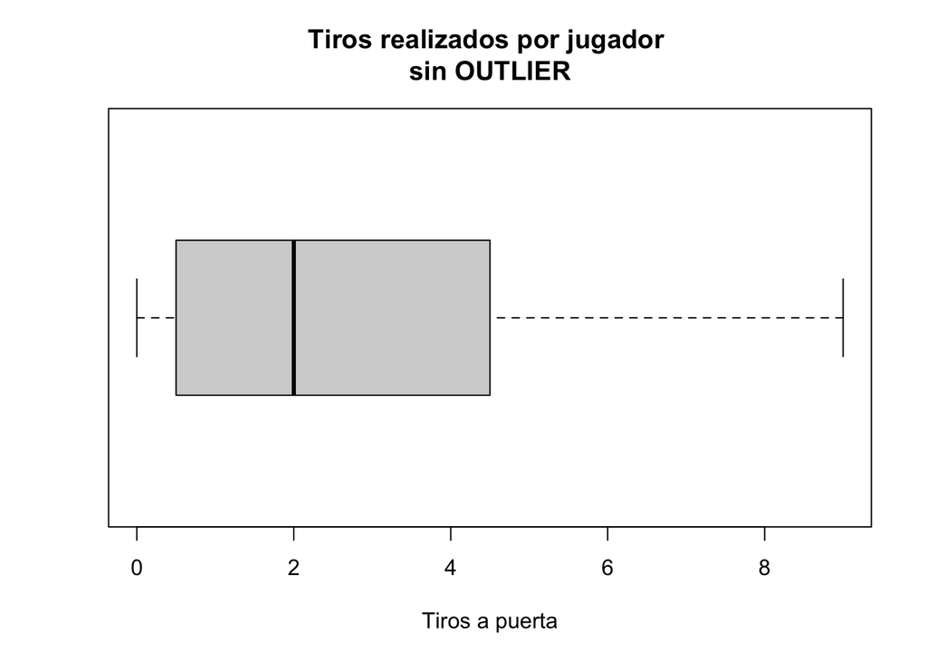

```r
boxplot(worldcup.Spain.sin.outliers$Shots, main="Tiros realizados por jugador \nsin OUTLIER", xlab= "Tiros a puerta", horizontal = TRUE)
```

## 5.1 Comentario

Podemos comprobar en la tabla “**worldcup.Spain**” que el valor 22 del outlier en el índice 19 pertenece a **Villa** delantero que ha jugado bastantes minutos con algunos pases y pocas entradas.

# 6 Agrupaciones de valores (2.5)

- Obtener un resumen de valores (mínimo, cuartiles, media y máximo) de la variable `Pases` en función de los valores de la variable `Posición`. Indicación: podéis usar la función `by` de `R`.
- Obtener un boxplot de la variable `Pases` en función de los valores de la variable `Posición`.
- Interpretar los resultados

## Solución

```r
# para poder sacar los cuartiles y la mediana necesitamos la función "summary", pero como a "summary" solo puede pasar un dataframe como argumentio, necesitamos la función "by" a la que sí se le pueden pasar dos variables y una función a calcular.

by(worldcup.Spain$Passes, worldcup.Spain$Position, summary)
```

```
## worldcup.Spain$Position: Defender
##    Min. 1st Qu.  Median    Mean 3rd Qu.    Max.
##     1.0    72.5   276.5   213.0   307.2   402.0
## ------------------------------------------------------------
## worldcup.Spain$Position: Forward
##    Min. 1st Qu.  Median    Mean 3rd Qu.    Max.
##    12.0    31.0    50.0    77.0   109.5   169.0
## ------------------------------------------------------------
## worldcup.Spain$Position: Goalkeeper
##    Min. 1st Qu.  Median    Mean 3rd Qu.    Max.
##      67      67      67      67      67      67
## ------------------------------------------------------------
## worldcup.Spain$Position: Midfielder
##    Min. 1st Qu.  Median    Mean 3rd Qu.    Max.
##   16.00   46.75   98.00  212.50  423.50  563.00
```

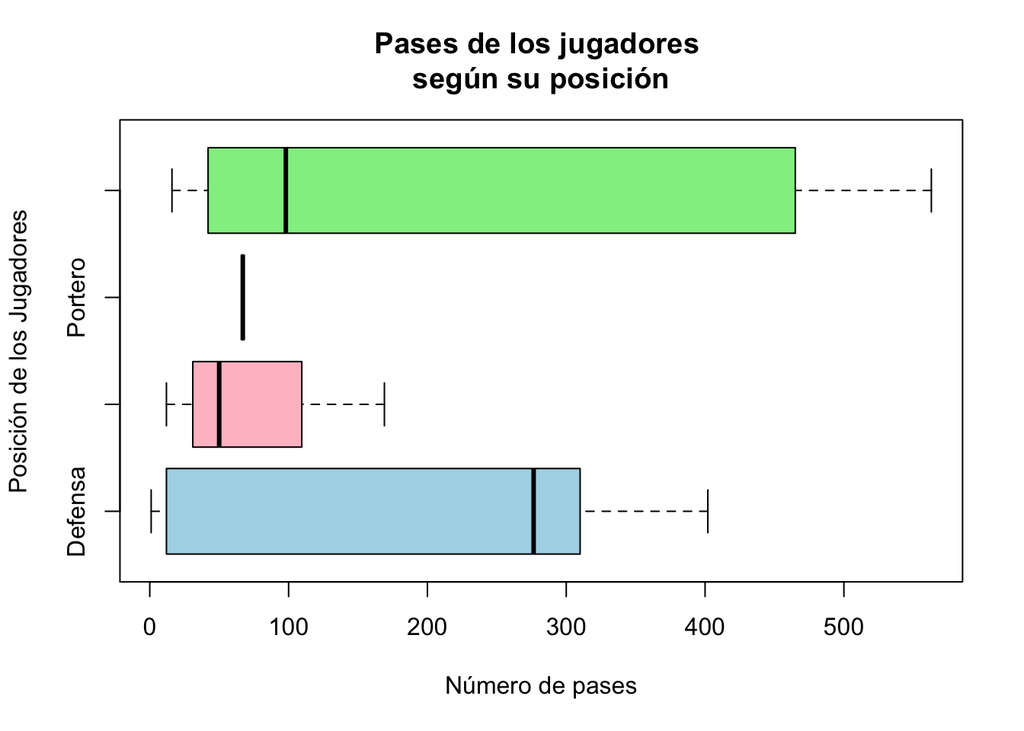

```r
# vamos a graficar un boxplot en horizontal, con los nombres de las posiciones en castellano de la variable "passes" en función de la posición de los jugadores.

boxplot(Passes~Position, worldcup.Spain, main = "Pases de los jugadores \nsegún su posición", col= c("lightblue","pink","blue", "lightgreen"), names = c("Defensa","Delantero","Portero","Mediocampo"), xlab = "Número de pases", ylab = "Posición de los Jugadores", horizontal= TRUE)
```

```r
# hemos añadido color, título principal, nombre a los ejes, etc. Siempre se pueden añadir más detalles al gráfico en función de los que se quiera mostrar o representar.
```

## 6.1 Comentarios

Si observamos el boxplot podemos ver que la posición de **portero** tiene **67** pases en total, por lo que su mediana y cuartiles vana a ser todos iguales, el portero es, **Casillas**.

La posición de **delantero** tampoco posee muchos pases en relación a las posiciones de defensas y mediocentro. Los delanteros tienen una mayor dispersión desde la mediana(*50*) al tercer cuartil(*109.5*) viendose así el boxplot asimétrico con respecto a la mediana y con una cola hacia la derecha con un max de 169 pases realizados por **Villa**.

Pero donde podemos ver mas asimetria desde Q1 hacia la mediana y de la mediana hasta Q3 es la posición de **mediocampo**. Con una mayor compresión de los datos entre Q1(*46.75*) y la mediana(*98*) y siendo notable la dispersión de datos entre la mediana y Q3(*423.50*) con una cola hacia la derecha siendo el máximo 563 pases por parte del mediocentro **Xavi**.

El **IQR** de 376,75 representa el 50% de los pases realizados por los jugadores en posición de mediocampo.

Para terminar de comentar todas las cajas, tenemos la posicón de **defensa**, en la que ocurre lo contrario que con los mediocampo. En esta posición la dispersión de los datos es mayor entre el primer cuartil, Q1(*72,5*), y la mediana(*276.5*), esto es debido a que, de los 6 defensas del equipo, 4 tienen mas de **250** pases, lo que hace dibujar la caja tan estrecha o concentrada desde la mediana al tercer cuartil, Q3(*307.2*).

Para concluir podemos observar que la mayoría de los pases realizados por el equipo de España lo tienen las posiciones de defensa y mediocentro. Esto tiene mucho sentido en el ambito deportivo ya que son las posiciones que más mueven el balón para distribuir juego y porque el número de delanteros y porteros en relación con las otras posiciones en este deporte.

# 7 Referencias Bibliográficas

1.

CienciasMatematicasInformatica2021UIB. Lección 12 descripción de datos cuantitativos | AprendeR parte i [Internet]. 2021. Available from: https://aprender-uib.github.io/AprendeR1/chap-quan.html#medidas-de-dispersi%C3%B3n